# STAT443 A3

Mark Lin

2024-11-29

# Q1a)

```r
data <- read.csv("Salmon.csv", header=TRUE)
SalmonTS <- ts(data,start=c(2012, 1), end=c(2021,12), frequency=12)
set.seed(123)
```

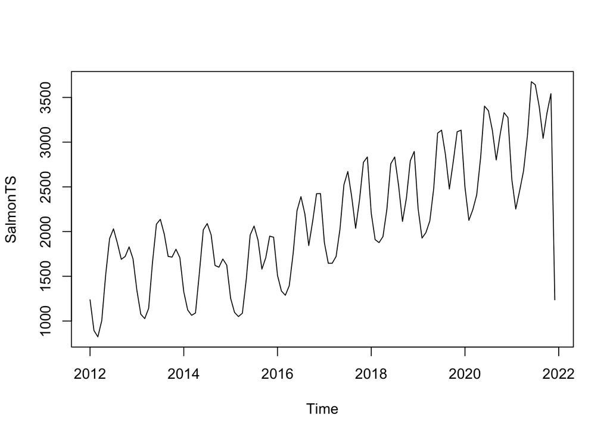

```r
plot(SalmonTS)
```

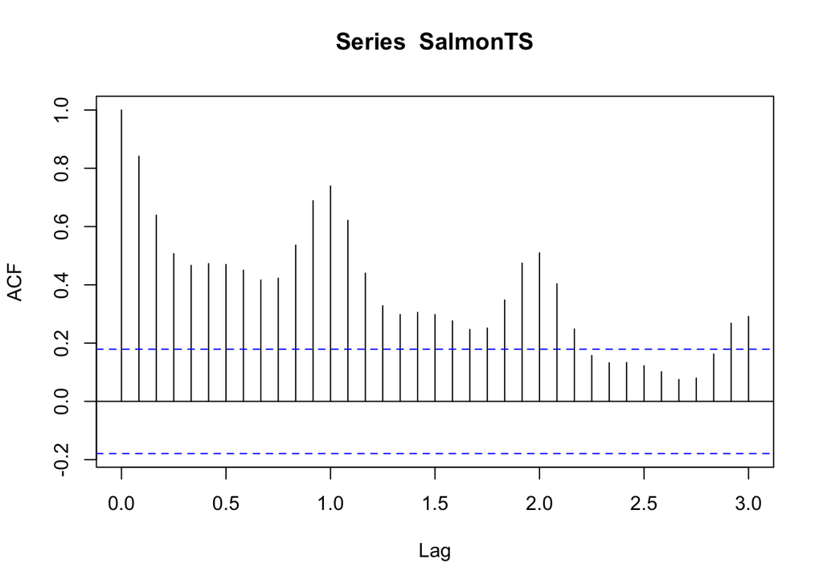

```r
acf(SalmonTS,lag.max = 36)
```

Taking a look at the plot of `SalmonTS`, we can see a both a trend and seasonality pattern. From the ACF plot of `SalmonTS`, we can confirm there is seasonality with a period of 12. We can also notice a linear decay in the, unreliably, by expanding the acf `lag.max` to 36, indicating a linear trend as well. I can conclude that this series is not stationary.

# Q1b)

```r
training.data <- window(SalmonTS, end=c(2020,12))
test.data <- window(SalmonTS, start=c(2021,1))

ses.model <- HoltWinters(training.data, beta=FALSE,gamma=FALSE)
des.model <- HoltWinters(training.data,gamma=FALSE)
hw.additive <- HoltWinters(training.data,seasonal="additive")
hw.multiplicative <- HoltWinters(training.data,seasonal="multiplicative")

pred.ses <- predict(ses.model,n.ahead=12)
pred.des <- predict(des.model,n.ahead=12)
pred.hw.additive <- predict(hw.additive,n.ahead=12)
pred.hw.multiplicative <- predict(hw.multiplicative,n.ahead=12)

apse.ses <- mean((pred.ses - test.data)^2)
apse.des <- mean((pred.des - test.data)^2)
apse.hw.additive <- mean((pred.hw.additive - test.data)^2)
apse.hw.multiplicative <- mean((pred.hw.multiplicative - test.data)^2)

apse.ses
```

```
## [1] 598444.7
```

```r
apse.des
```

```
## [1] 526749.5
```

```r
apse.hw.additive
```

```
## [1] 435545.5
```

```r
apse.hw.multiplicative
```

```
## [1] 428247.6
```

Based on the APSE, we want to would want to choose the multiplicative HW model.

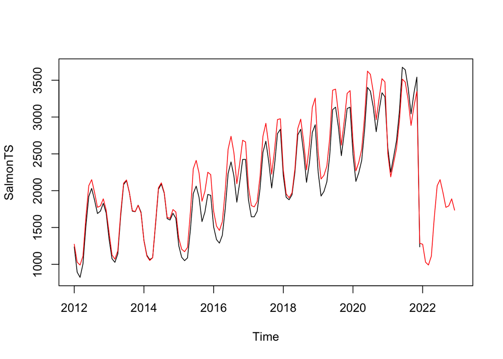

```r
full.hw.multiplicative <- HoltWinters(SalmonTS,seasonal="multiplicative")
fitted.values <- full.hw.multiplicative$fitted[,1]
forecast.values <- predict(full.hw.multiplicative, n.ahead=12)
combined.values <- ts(c(fitted.values, forecast.values),start=c(2012, 1),end=c(2022,12), frequency=12)

plot(SalmonTS,xlim=c(2012,2023))
lines(combined.values,lwd=1,col="red")
```

# Q1c)

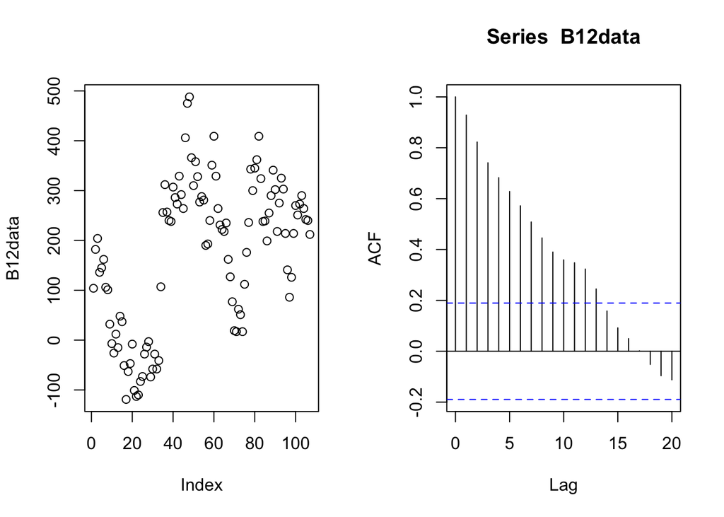

```r
B12data <- diff(data$X1607, lag=12)
par(mfrow=c(1,2))
plot(B12data)
acf(B12data)
```

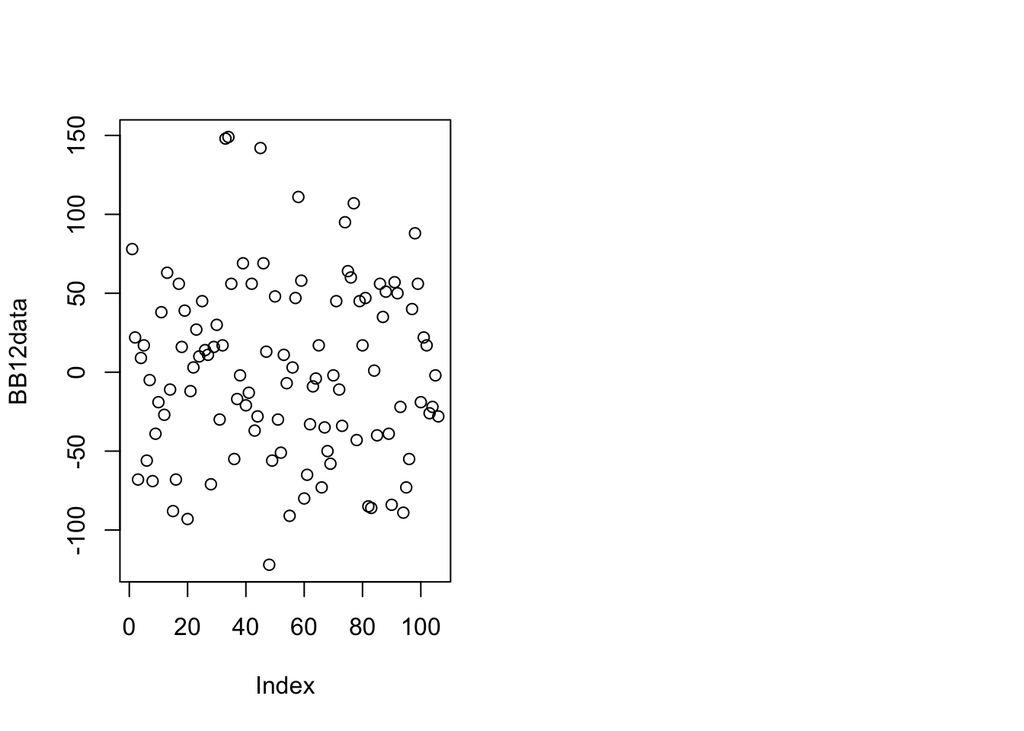

```r
BB12data <- diff(B12data, lag=1)
par(mfrow=c(1,2))
plot(BB12data)

residuals <- data.frame(
  Index = time(residuals(full.hw.multiplicative)),
  Residuals = as.numeric(residuals(full.hw.multiplicative))
)

par(mfrow=c(1,2))
```

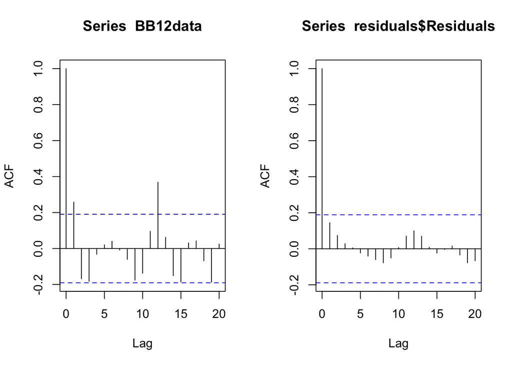

```r
acf(BB12data)
acf(residuals$Residuals)
```

After deseasonalizing by differencing by 12, I noticed there was still a trend to the data, through the slow linear decay in the acf plot. Trend differencing by 1 gives us data that is stationary, which we can confirm with the acf plot.

Comparing it to the acf plot of my model residuals, the HW multiplicative model perofmrs better than differencing for this data. The acf plot indicates they are less correlated with fewer spikes above the 95% interval.

Note:
$$Cov(Z_t,Z_{t+h})=
\begin{cases}
1 & h=0 \\
0 & o/w
\end{cases}$$

Thus, $Cov(X_t,X_{t+h})$ is a stationary process.

#Q2b)

From part (a), we can find:

```r
A <- matrix(c(2.25,0,-1,0,2.25,0,-1,0,2.25),nrow=3,ncol=3)
a <- solve(A) %*% c(2.25,0,-1)
```

Thus, the best linear predictor is $X_{t+1}=X_t$.

#Q2c)

When $h\geq 3$ then $X_{t+h}$ is uncorrelated with $X_t$. The best linear predictor is then just the mean. Since $X_t$ is stationary, from (a), we get $\hat X_{t+h}=0$.

#Q3a)

$$\begin{aligned}
E[(X_{n+h}-\phi(X_n))^4]&=E[(X_{n+h}-\phi X_n)^2]^2 \\
&=Var(X_{n+h}-\phi(X_n))^2 \\
&=Var(X_{n+h}+\phi^2Var(X_n)-2\phi Cov(X_{n+h},X_n) \\
&= 2 +2\phi^2-4\phi^{(1-|h|)}
\end{aligned}$$

#Q3b)

$$\begin{aligned}
&\frac{d}{d\phi}2 +2\phi^2-4\phi^{(1-|h|)} \\
\phi&=(1-|h|)^{(1/|h|)}
\end{aligned}$$

#Q3c)

$$\begin{aligned}
E[(X_{n+2}-(1-2)^{(1/2)}\times X_n)^4]&=0.25
\end{aligned}$$
The risk for the 2-step forecast is $0.25$

#Q3d)

```r
data <- read.csv("Q3.csv",header=TRUE)
x500 <- data[500,]
h <- 3
phi <- -1.259921
x503 <- phi * x500

risk <- 2+2*(1 - abs(h))^(2/abs(h)) - 4 * (1 - abs(h))^(1-abs(h))
risk
```

```
## [1] NaN
```

#Q4a)

We need to satisfy: $1-\alpha^2B^2$ s.t. the roots lie outside the unit circle. This is true when $|\alpha|<1|$.

It must also satisfy: $(1-(1/(1-\alpha))B)$ s.t. the roots lie outside the unit circle. Thus, $|alpha|<1$.

#Q4b)

We also need to satisfy $1-\alpha^2B^2$. Thus, the process is causal for $|alpha|<1$.

#Q4c)

$1-(1/(1-\alpha))B$. Roots must lie outside unit circle. Thus, $|1-\alpha|>1\implies\alpha <0\text{ or }\alpha>2$

#Q4d)

$$\begin{aligned}
X_t-(0.5)^2X_{t-2}&=Z_t-2Z_{t-1} \\
X_t-0.25X_{t-2}&=Z_t-2Z_{t-1}
\end{aligned}$$

To get the $MA(\infty)$ representation:

$$X_t=Z_t-2Z_{t-1}+0.25X_{t-2} \\
X_{t-2}=Z_{t-2}-2Z_{t-3}+0.25X_{t-4} \\
\vdots \\
X_t=Z_t-2Z_{t-1}+0.25Z_{t-2}-0.5Z_{t-3}+0.00625Z_{t-4}+\dots$$